# Regression Model checking

## LINEAR REGRESSION with iid $N(0,\sigma^2)$ errors

### Section 9.2.6 An Example in J. Albert’s book

```r
 rm(list=ls())
library(LearnBayes)
```

However, **DO NOT USE LearnBayes package** for your project, since the package has only an educational purpose

```r
data(birdextinct)
attach(birdextinct)

birdextinct
```

| species | time | nesting | size | status |
| --- | --- | --- | --- | --- |
| Sparrowhawk | 3.030 | 1.000 | 0 | 1 |
| Buzzard | 5.464 | 2.000 | 0 | 1 |
| Kestrel | 4.098 | 1.210 | 0 | 1 |
| Peregrine | 1.681 | 1.125 | 0 | 1 |
| Grey_partridge | 8.850 | 5.167 | 0 | 1 |
| Quail | 1.493 | 1.000 | 0 | 0 |
| Red-legged_partridge | 7.692 | 2.750 | 0 | 1 |
| Pheasant | 3.846 | 5.630 | 0 | 1 |
| Water_rail | 16.667 | 3.000 | 0 | 1 |
| Corncrake | 4.219 | 4.670 | 0 | 0 |

[output cut: 52 more lines]

The DATASET concerns EXTINCTION of BIRDS

Measurements on breedings (“in cova”) pairs of landbird species were collected from 16 islands about Britain over several decades.

For each pairs (62 in total), the dataset records:  
* SPECIES = name of bird species  
* TIME = average time of extinction on the islands  
* NESTING = average number of nesting pairs  
* SIZE = size of the species, 1 or 0 if large or small  
* STATUS = status of the species, 1 or 0 if resident or migrant.

LINEAR MODEL for TIME, using NESTING, SIZE, STATUS as covariates.

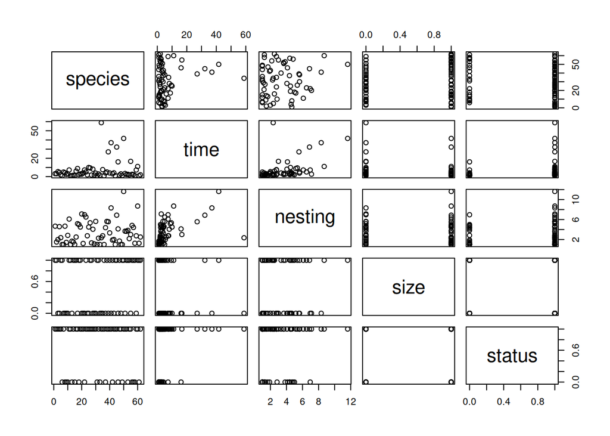

```r
plot(birdextinct)
```

Better consider TIME in the log scale!

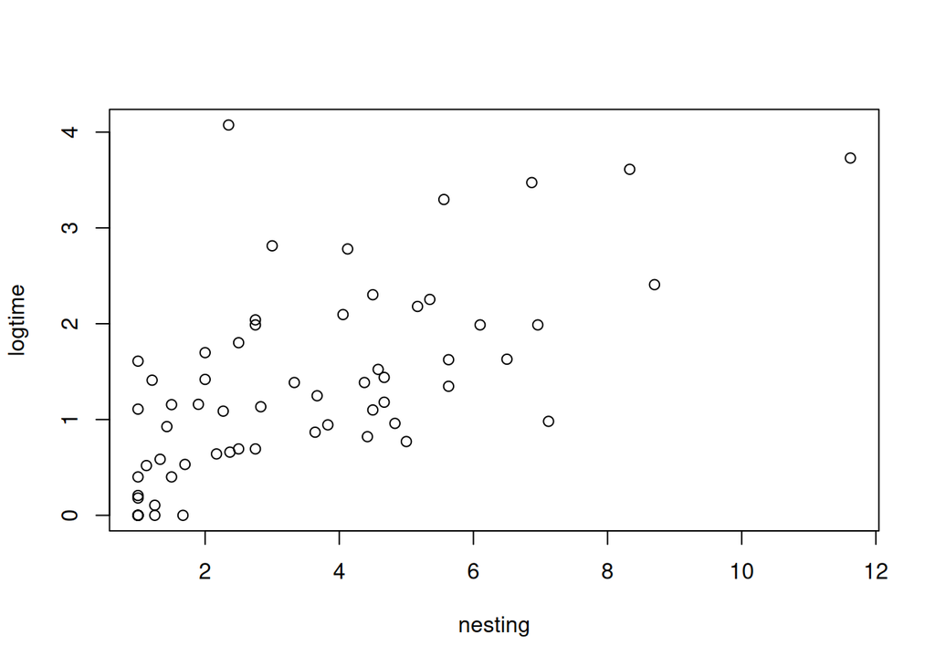

```r
logtime=log(time)
plot(nesting,logtime)
```

POSITIVE CORRELATION between these two variables!

OUTLIER ??: probably datapoints with log(time)>3; we will monitor at least those datapoints.

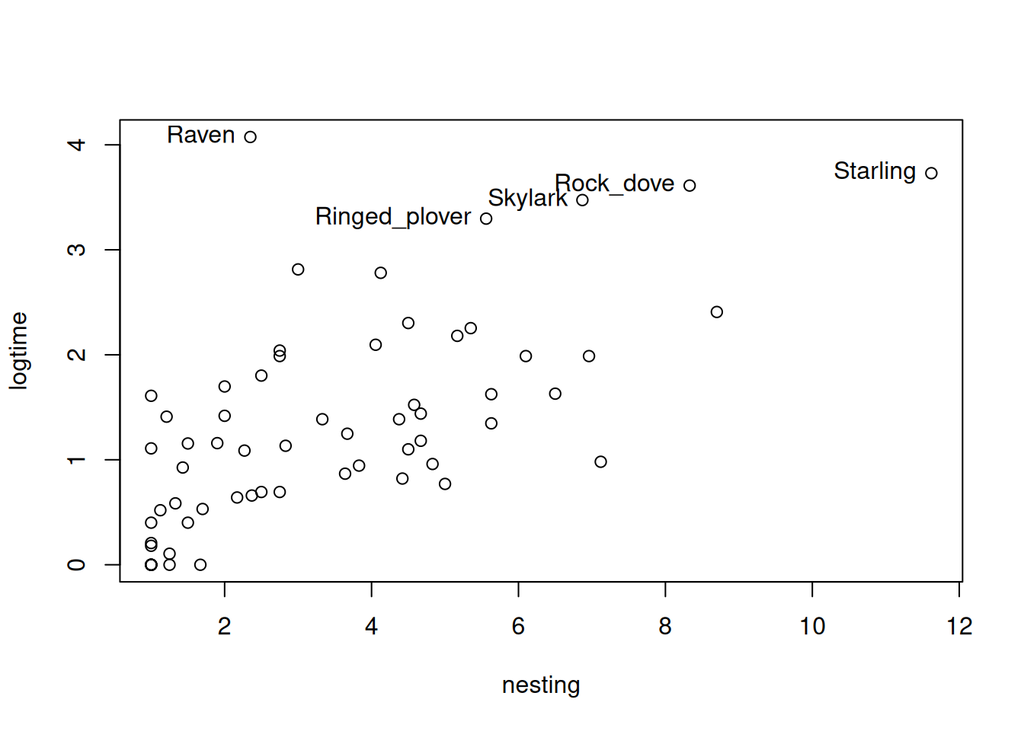

```r
out = (logtime > 3)
plot(nesting,logtime)
text(nesting[out], logtime[out], label=species[out], pos = 2)
```

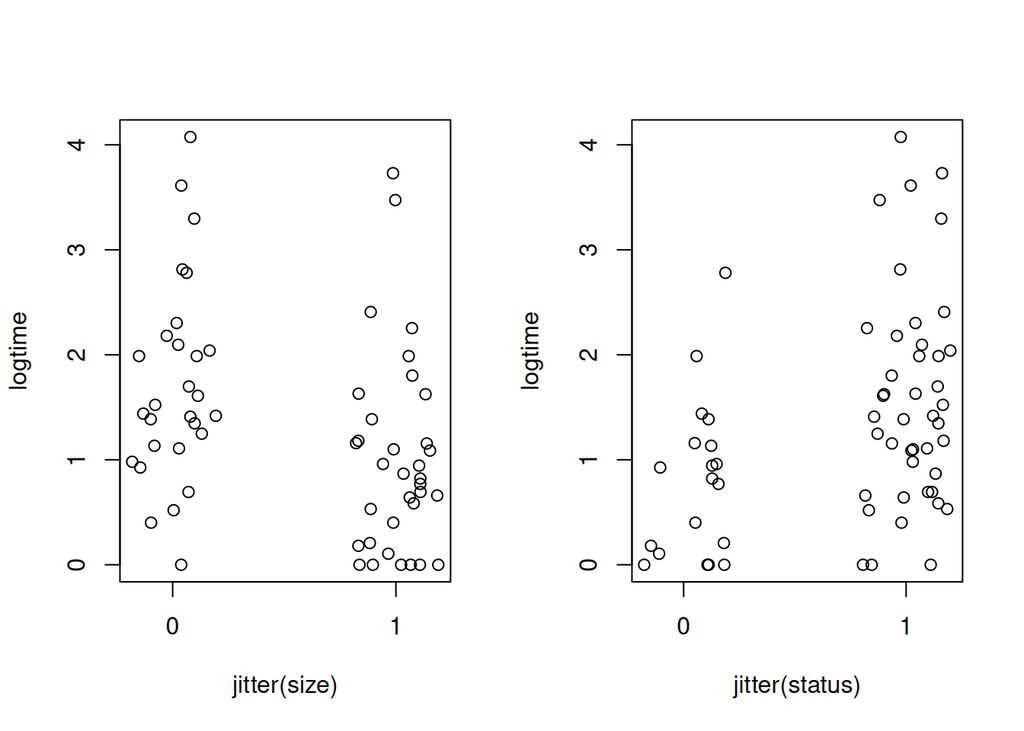

```r
# Command JITTER adds a small amount of noise to a numeric vector
par(mfrow=c(1,2))
plot(jitter(size),logtime,xaxp=c(0,1,1))
plot(jitter(status),logtime,xaxp=c(0,1,1))
```

##### ML/frequentist estimates

```r
fit=lm(logtime~nesting+size+status,data=birdextinct,x=TRUE,y=TRUE)
summary(fit)
```

```
##
## Call:
## lm(formula = logtime ~ nesting + size + status, data = birdextinct,
##     x = TRUE, y = TRUE)
##
## Residuals:
##     Min      1Q  Median      3Q     Max
## -1.8410 -0.2932 -0.0709  0.2165  2.5167
##
## Coefficients:
##             Estimate Std. Error t value Pr(>|t|)
## (Intercept)  0.43087    0.20706   2.081 0.041870 *
## nesting      0.26501    0.03679   7.203 1.33e-09 ***
## size        -0.65220    0.16667  -3.913 0.000242 ***
## status       0.50417    0.18263   2.761 0.007712 **
## ---
## Signif. codes:  0 '***' 0.001 '**' 0.01 '*' 0.05 '.' 0.1 ' ' 1
##
## Residual standard error: 0.6524 on 58 degrees of freedom
## Multiple R-squared:  0.5982, Adjusted R-squared:  0.5775
## F-statistic: 28.79 on 3 and 58 DF,  p-value: 1.577e-11
```

NESTING is a strong effect.

```r
fit$x
```

```
##    (Intercept) nesting size status
## 1            1   1.000    0      1
## 2            1   2.000    0      1
## 3            1   1.210    0      1
## 4            1   1.125    0      1
## 5            1   5.167    0      1
## 6            1   1.000    0      0
## 7            1   2.750    0      1
## 8            1   5.630    0      1
## 9            1   3.000    0      1
## 10           1   4.670    0      0
## 11           1   4.056    0      1
## 12           1   1.000    0      1
## 13           1   6.960    0      0
## 14           1   1.670    0      0
```

[output cut: 50 more lines]

```r
fit$y
```

```
##         1         2         3         4         5         6         7         8
## 1.1085626 1.6981811 1.4104990 0.5193889 2.1804175 0.4007875 2.0401808 1.3470336
##         9        10        11        12        13        14        15        16
## 2.8134307 1.4395981 2.0955609 1.6094379 1.9877374 0.0000000 3.2968364 1.1333357
##        17        18        19        20        21        22        23        24
## 1.3862944 2.7806189 1.2481811 3.6119174 1.9877374 0.9262411 1.4187616 0.6931472
##        25        26        27        28        29        30        31        32
## 2.3025851 0.9809542 1.5232262 4.0745499 3.4737661 0.9442949 0.7701082 0.0000000
##        33        34        35        36        37        38        39        40
## 1.0875513 2.2538149 2.4079356 1.9877374 1.3862944 0.8675206 0.9597333 1.1808065
##        41        42        43        44        45        46        47        48
## 0.5312163 0.5850050 0.1806535 1.1584523 0.8211005 0.1052605 0.0000000 0.0000000
##        49        50        51        52        53        54        55        56
## 0.2070142 1.8018748 1.1553076 0.6931472 1.6245235 0.6595904 0.4007875 0.0000000
##        57        58        59        60        61        62
## 1.6296326 1.0996118 0.6408007 3.7297094 0.0000000 0.0000000
```

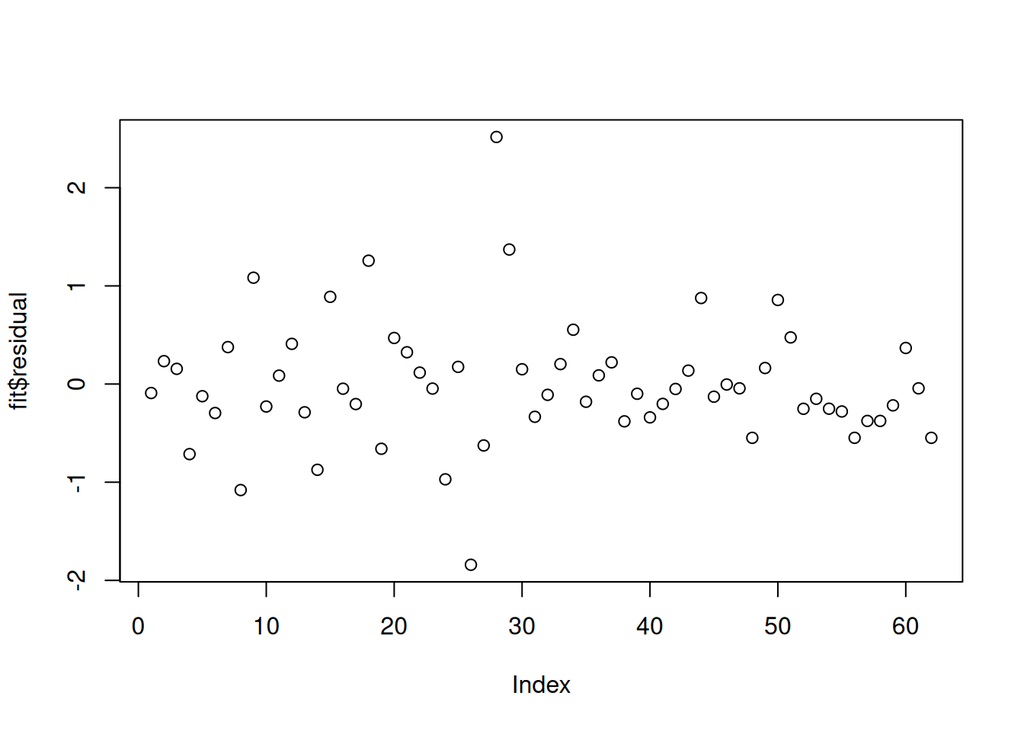

```r
plot(fit$residual)
```

The function *blinreg* adopts a Zellner’s g-prior:

The output is a Monte Carlo sample (iid) from the posterior of $\theta=(\beta,\sigma)$

It gives a simulated sample from the joint posterior distribution of the regression vector and the error standard deviation for a linear regression model with a (noninformative or) Zellner g prior.

INPUT: response vector $y$, design matrix $X$, num. of iterations, prior list with components c0 and beta0 of Zellner’s g prior: $N_p(b0, \sigma^2 (c0 (X^t X)^{-1})) \times 1/\sigma^2$

```r
prior=list(b0=c(0,0,0,0), c0=10)  #c0\in [10,100]
theta2.sample=blinreg(fit$y,fit$x,5000,prior=prior)
```

> LET US FOCUS on the posterior OUPUT rather than on this “silly” prior

The analysis below is an example of the output you could monitor whichever is the prior.

In this case, the posterior distribution can be factorized as the posterior conditional of $\beta$, given $\tau$ and $y$:

$\beta |\tau, y\sim N_p(c0/(c0+1)(b0/c0 + \hat \beta), \sigma^2 * c0/(c0+1)* (X^t X)^{-1})) )$$

while the marginal posterior of $\tau$, given $y$, is gamma$(n/2, s^2/2+ ...)$

##### Posterior plots

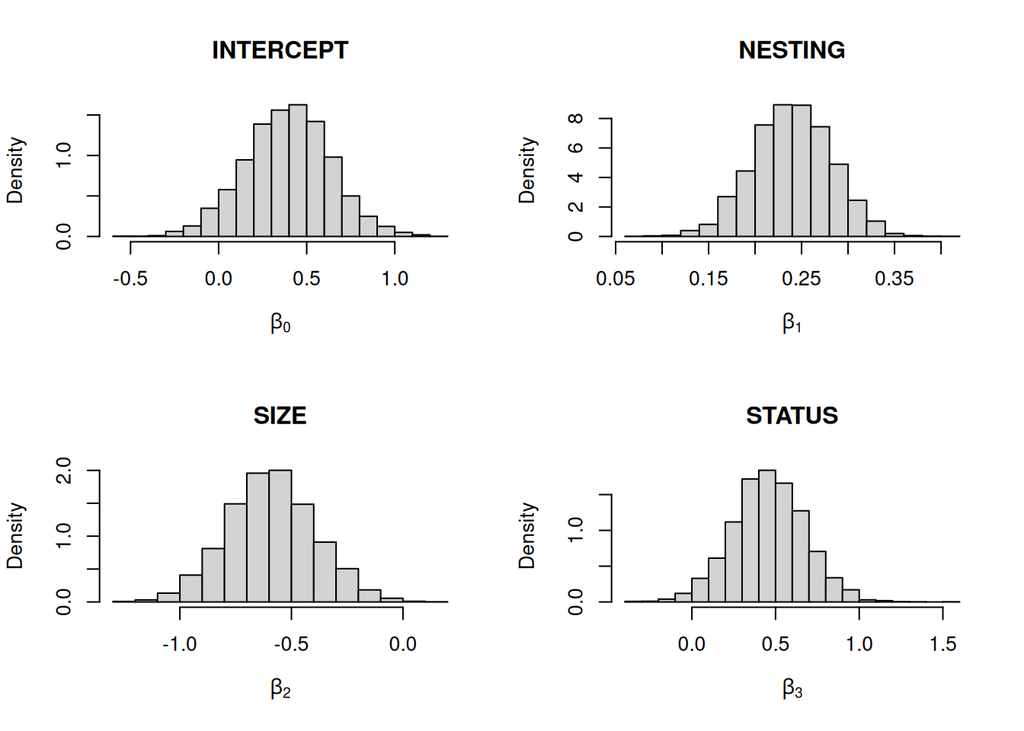

```r
par(mfrow=c(2,2))
hist(theta2.sample$beta[,1],main="INTERCEPT",xlab=expression(beta[0]),prob=T)
hist(theta2.sample$beta[,2],main="NESTING",xlab=expression(beta[1]),prob=T)
hist(theta2.sample$beta[,3],main="SIZE",xlab=expression(beta[2]),prob=T)
hist(theta2.sample$beta[,4],main="STATUS",xlab=expression(beta[3]),prob=T)
```

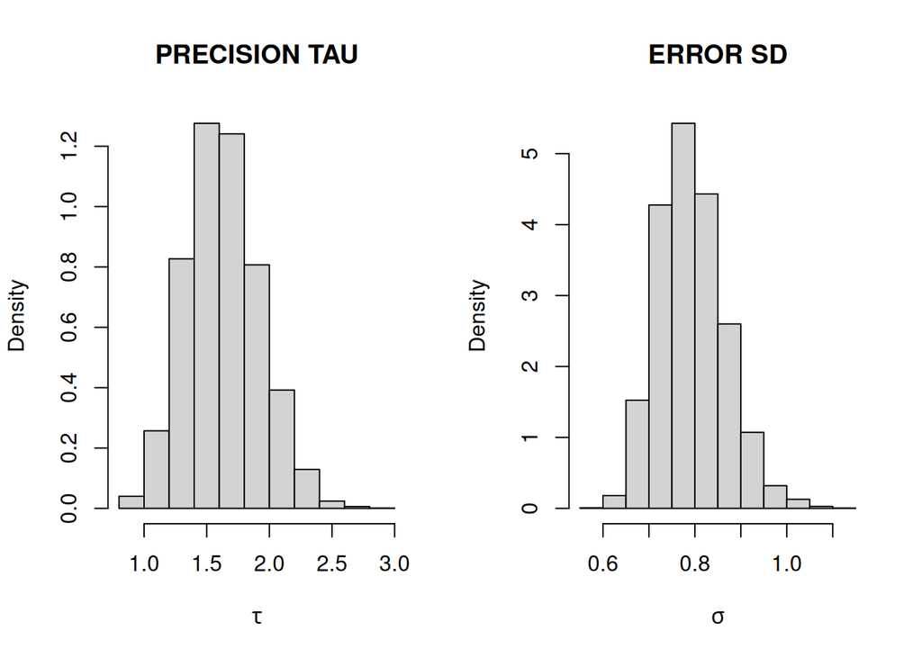

```r
par(mfrow=c(1,2))
hist(1/((theta2.sample$sigma)^2),main="PRECISION TAU",xlab=expression(tau),prob=T)
hist(theta2.sample$sigma,main="ERROR SD",xlab=expression(sigma),prob=T)
```

Posterior quantiles and means of beta parameters and $\sigma$:

```r
apply(theta2.sample$beta,2,quantile,c(.05,.5,.95))
```

```
##     X(Intercept)  Xnesting      Xsize    Xstatus
## 5%   -0.01227809 0.1704870 -0.9146123 0.09734392
## 50%   0.39828546 0.2401062 -0.5919757 0.45677218
## 95%   0.78719993 0.3081708 -0.2554029 0.81142322
```

```r
apply(theta2.sample$beta,2,mean)
```

```
## X(Intercept)     Xnesting        Xsize      Xstatus
##    0.3946791    0.2398171   -0.5901380    0.4584716
```

```r
fit$coefficients #  frequentist estimates
```

```
## (Intercept)     nesting        size      status
##   0.4308716   0.2650140  -0.6521982   0.5041655
```

```r
quantile(theta2.sample$sigma,c(.05,.5,.95))
```

```
##        5%       50%       95%
## 0.6843443 0.7868069 0.9210763
```

```r
#posterior mean of sigma is larger  than the frequentist estimate
mean(theta2.sample$sigma)
```

```
## [1] 0.7930034
```

```r
sqrt(sum(fit$residuals^2)/(62-4)) #frequentist estimate
```

```
## [1] 0.6524084
```

##### Estimating mean extinction times

We’d like to estimate the function of beta: $E(Y_{new}|\beta, X1)=X_1*\beta$, $X_1$ is a “new” covariate matrix; this function is a LINEAR COMBINATION of the beta parameters.

For instance, we want to estimate the average response (extinction time) of a new species with covariates cov4=c(1,4,1,1), i.e. we estimate
$$E(Y_{new}|\beta,
cov4)=\beta_0+4\beta_1+\beta_2+\beta_3$$
We use a function of the LearnBayes package (*blinregexpected*), but in general it is easy to simulate the function above if we have the whole MC Markov chain from the posterior.

```r
cov1=c(1,4,0,0) #A
cov2=c(1,4,1,0) #B
cov3=c(1,4,0,1) #C
cov4=c(1,4,1,1) #D
X1=rbind(cov1,cov2,cov3,cov4)
mean.draws=blinregexpected(X1,theta2.sample)
```

We plot the marginal posterior distributions of 4 parameters that represent average values of the response relative to “new” covariates.

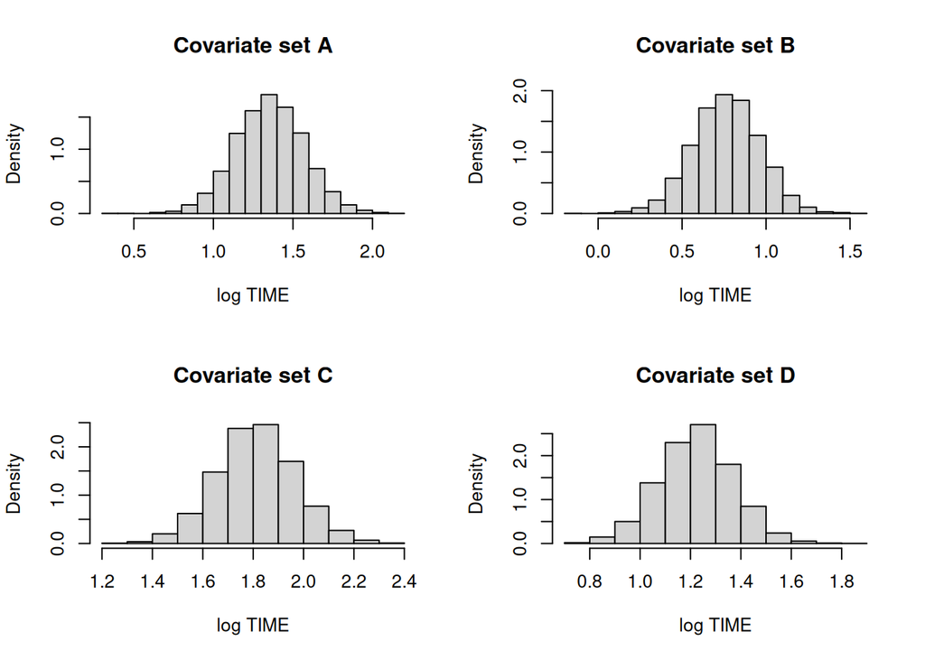

```r
c.labels=c("A","B","C","D")
par(mfrow=c(2,2))
for (j in 1:4)
hist(mean.draws[,j], main=paste("Covariate set",c.labels[j]),xlab="log TIME",prob=T)
```

##### Posterior predictive distributions - Predicting extinction time

Before we simulated the posterior of E(y_new|X1) - that is a function of the 4 regression parameters.

Now we want to simulate the predictive distribution of y_new, relative to the same “new covariates” X1.

This is easy to do: we simulate from the likelihood of new data when the parameters are the different iteration of the posterior simulated values.

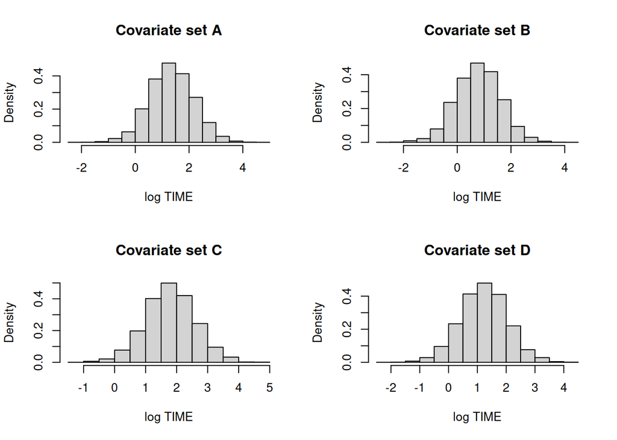

```r
pred.draws=blinregpred(X1,theta2.sample)

c.labels=c("A","B","C","D")
par(mfrow=c(2,2))
for (j in 1:4)
hist(pred.draws[,j],main=paste("Covariate set",c.labels[j]),xlab="log TIME",prob=T)
```

#### MODEL CHECKING via POSTERIOR PREDICTIVE DISTRIBUTIONS

From the book Gelman et al. (2014) - $Y_i^{new}$ is “the replicated data that could have been observed, or, to think predictively, as:

*the data that we would see tomorrow if the experiment that produced* $y_i$ *today were replicated with the same model and the same value of* $\theta$ that produced the observed data $y_i$

If the model fits, then replicated data generated under the model should look similar to observed data.

To put another way, the observed data should look PLAUSIBLE under the posterior predictive distribution.

This is a self-consistency test! Any systematic differences between the simulations and the data indicate potential failings of the model.

As an ALTERNATIVE, apply the CROSS-VALIDATION approach - see BELOW!

Specifically, we compute the predictive distribution of $Y_1,\ldots,Y_{62}$, given the same covariates associated to the $y_i$’s in the observed sample. In this case, because the example is simple, we obtain iid draws from the posterior predictive (simulating independent draws from the likelihood with each iid simulated value from the posterior).

More in general, it is easy to simulate from the posterior predictive of each $Y_i$ simulating one draw from the likelihood for each MCMC draw of the posterior.

We also compute 0.05- and 0.95-quantiles of the posterior predictive of each $Y_i$, $i=1,\ldots,62$.

```r
pred.draws=blinregpred(fit$x,theta2.sample)
pred.sum=apply(pred.draws,2,quantile,c(.05,.95))
```

Plot the posterior predictive 90% CI and the datapoints and consider species datapoints outside these intervals as OUTLIERS

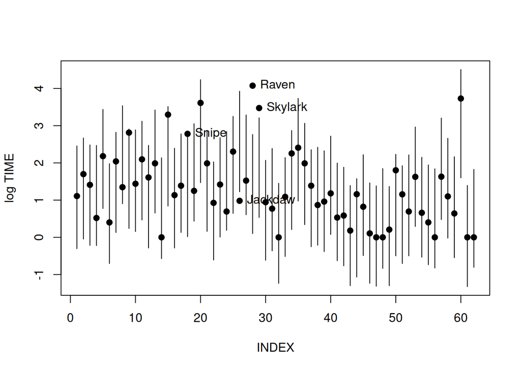

```r
ind=1:length(logtime)
matplot(rbind(ind,ind),pred.sum,type="l",lty=1,col=1,xlab="INDEX",ylab="log TIME")
points(ind,logtime,pch=19)

out=(logtime>pred.sum[2,]| logtime<pred.sum[1,])
text(ind[out], logtime[out], label=species[out], pos = 4)
```

#### BAYESIAN PREDICTIVE p-values

More precisely, we should call them as **POSTERIOR PREDICTIVE TAIL PROBABILITIES**:
$$\min(
P(Y_i^{new}>y_i|x_i,data), P(Y_i^{new}<y_i|x_i, data)),
i=1,\ldots,n$$
Compute how many simulated values from the predictive of $Y_i^{new}$ are $> y_i$ (over the total numumber of simulations): this is an estimate of $P(Y_i^{new}>y_i|data, x_i)$

```r
ind_pvalue=t((t(pred.draws)>logtime))
pred.suptail=apply(ind_pvalue,2,sum)/5000
prob.tail<-rep(0, 62)
for (i in 1 : 62)
  prob.tail[i]=min(pred.suptail[i],1-pred.suptail[i])
## this is the PREDICTIVE TAIL PROBABILITY of item i
```

This is the *PREDICTIVE TAIL PROBABILITY* of item $i$, $i=1,\ldots,n$:  
* if this number is close to 1/2, the corresponding predictive distribution “explain” well the datapoint,  
* if this number is close to 0, the datapoint is an “outlier” for the model

In the following plot, let’s mark as OUTLIERS those species such that the BAYESIAN PREDICTIVE p-value is smaller than 0.05 (or than 0.1)

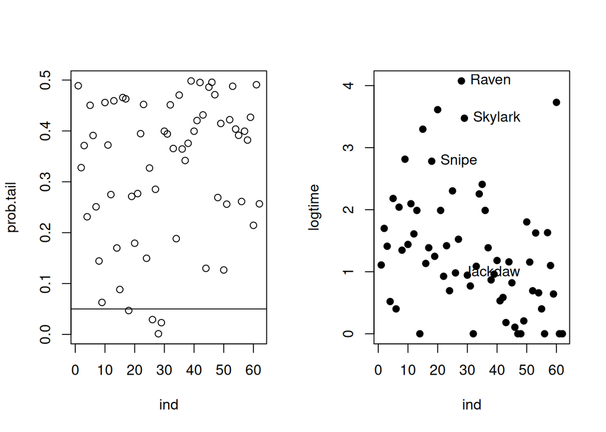

```r
par(mfrow=c(1,2))
plot(ind, prob.tail)
abline(h=0.05)

plot(ind,logtime,pch=19)

out2=(prob.tail<0.05)
text(ind[out2], logtime[out2], label=species[out2], pos = 4)
```

Then compute the difference between the predictive mean and observed datapoint, over the sd of the predictive distribution. This is the **predictive Bayesian error**.

Consider as an OUTLIER all data such that the corresponding residual is LARGE e.g. its absolute value is larger than 2 (or 3)

```r
pred.mean=apply(pred.draws,2,mean)
pred.sd=apply(pred.draws,2,sd)
```

Bayesian residuals - threshold fixed at 2

```r
bres= (pred.mean- logtime)/pred.sd
out2 = (abs(bres) > 2)
```

Plots

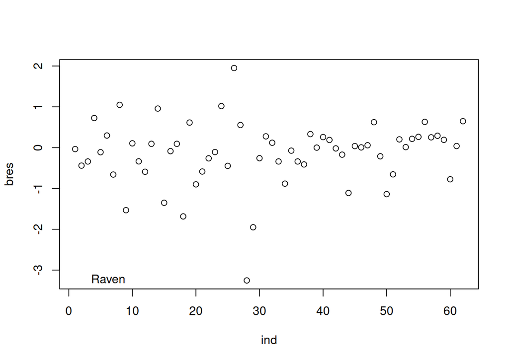

```r
par(mfrow=c(1,1))
plot(ind,bres,cex=1)
text(nesting[out2], bres[out2], label=species[out2], pos = 4)
```

#### Predictive goodness-of-fit: SUM of the squares of the predictive Bayesian residuals to compare different models

The “best” model is the one with the smallest value for this index

```r
sum(bres^2)
```

```
## [1] 38.98161
```

### LPML and $CPO_i$

Conditional density of each Y_i, given parameters, is Gaussian with mean $X*\beta$ and variance $\sigma^2$

We use the function *blinregexpected*, though we can simulate a MCMC from $X*\beta$

```r
 mean.draws.data=blinregexpected(fit$x,theta2.sample)
dim(mean.draws.data)
```

```
## [1] 5000   62
```

```r
cpo=seq(1,62)
for (i in 1:62){
cpo[i]=1/mean(1/dnorm(fit$y[i],mean.draws.data[,i], theta2.sample$sigma))
}

1/mean(1/dnorm(fit$y[2],mean.draws.data[,2], theta2.sample$sigma)) # this is  CPO[2] of item i=2
```

```
## [1] 0.4387296
```

```r
LPML=sum(log(cpo))
LPML
```

```
## [1] -67.46697
```

LPML has not a meaning *per se*, but it is meaningful when compared to LPML of other models

##### Repeat the analysis WITHOUT covariate “status”

```r
fit2=lm(logtime~nesting+size,data=birdextinct,x=TRUE,y=TRUE)
summary(fit2)
```

```
##
## Call:
## lm(formula = logtime ~ nesting + size, data = birdextinct, x = TRUE,
##     y = TRUE)
##
## Residuals:
##      Min       1Q   Median       3Q      Max
## -1.76083 -0.38290 -0.09753  0.38512  2.68075
##
## Coefficients:
##             Estimate Std. Error t value Pr(>|t|)
## (Intercept)  0.72970    0.18615   3.920 0.000233 ***
## nesting      0.28260    0.03821   7.395 5.79e-10 ***
## size        -0.66904    0.17565  -3.809 0.000335 ***
## ---
## Signif. codes:  0 '***' 0.001 '**' 0.01 '*' 0.05 '.' 0.1 ' ' 1
##
## Residual standard error: 0.688 on 59 degrees of freedom
## Multiple R-squared:  0.5454, Adjusted R-squared:   0.53
## F-statistic:  35.4 on 2 and 59 DF,  p-value: 7.923e-11
```

```r
fit2$x
```

```
##    (Intercept) nesting size
## 1            1   1.000    0
## 2            1   2.000    0
## 3            1   1.210    0
## 4            1   1.125    0
## 5            1   5.167    0
## 6            1   1.000    0
## 7            1   2.750    0
## 8            1   5.630    0
## 9            1   3.000    0
## 10           1   4.670    0
## 11           1   4.056    0
## 12           1   1.000    0
## 13           1   6.960    0
## 14           1   1.670    0
```

[output cut: 50 more lines]

```r
fit2$y
```

```
##         1         2         3         4         5         6         7         8
## 1.1085626 1.6981811 1.4104990 0.5193889 2.1804175 0.4007875 2.0401808 1.3470336
##         9        10        11        12        13        14        15        16
## 2.8134307 1.4395981 2.0955609 1.6094379 1.9877374 0.0000000 3.2968364 1.1333357
##        17        18        19        20        21        22        23        24
## 1.3862944 2.7806189 1.2481811 3.6119174 1.9877374 0.9262411 1.4187616 0.6931472
##        25        26        27        28        29        30        31        32
## 2.3025851 0.9809542 1.5232262 4.0745499 3.4737661 0.9442949 0.7701082 0.0000000
##        33        34        35        36        37        38        39        40
## 1.0875513 2.2538149 2.4079356 1.9877374 1.3862944 0.8675206 0.9597333 1.1808065
##        41        42        43        44        45        46        47        48
## 0.5312163 0.5850050 0.1806535 1.1584523 0.8211005 0.1052605 0.0000000 0.0000000
##        49        50        51        52        53        54        55        56
## 0.2070142 1.8018748 1.1553076 0.6931472 1.6245235 0.6595904 0.4007875 0.0000000
##        57        58        59        60        61        62
## 1.6296326 1.0996118 0.6408007 3.7297094 0.0000000 0.0000000
```

SAMPLING from the posterior with the Zellner g prior as before

```r
prior3=list(b0=c(0,0,0), c0=10)  #c0\in [10,100]
theta3.sample=blinreg(fit2$y,fit2$x,5000, prior=prior3)
```

##### LPML

```r
mean.draws3.data=blinregexpected(fit2$x,theta3.sample)
dim(mean.draws3.data)
```

```
## [1] 5000   62
```

```r
cpo3=seq(1,62)
for (i in 1:62){
cpo3[i]=1/mean(1/dnorm(fit$y[i],mean.draws3.data[,i], theta3.sample$sigma))
}


LPML3=sum(log(cpo3))
LPML3
```

```
## [1] -69.96752
```

##### The best model is the one with LARGEST LPML: which model is better, then?

```r
LPML; LPML3
```

```
## [1] -67.46697
```

```
## [1] -69.96752
```